# AI PYTHON ASSIGNMENT

## PROJECT 1

Q.2. Write a function which prints all the numbers divisible by 3 and 5

```python
n=int(input("Enternumber:\n"))
a=n%15
if(a==0):
    print("{} is divisible by 3 and 5".format(n))
else:
    print("{} is not divisible by 3 and 5".format(n))
```

```
Enternumber:
25
25 is not divisible by 3 and 5
```

Q.3. Write a program to check whether a given letter is vowel or consonant

```python
l=['a','e','i','o','u']
l2=['A','E','I','O','U']
l3=["I"]
char=0
char=str(input("ENTER LETTER:\n"))
if char==l[0] or char==l[1] or char==l[2] or char==l[3] or char==l[4]:
    print("{} is a vowel".format(char))
elif char==l2[0] or char==l2[1] or char==l2[3] or char==l2[4]:
    print("{} is a vowel".format(char))
elif char==l3[0]:
    print("{} is a vowel".format(char))
else:
    print("{} is not a vowel".format(char))
```

```
ENTER LETTER:
T
T is not a vowel
```

Q1.Take list of elements from the user and find the square root of each number in the list and store in it another list and print that list.

```python
import math
l=[]
x=int(input("Enter list size:\n"))

a=input("Enter numbers and separate them with single spaces:\n")
l=a.split()
l=[float(i) for i in l]

print("List:", l)

l2=[]
for a in l:
    l2.append(math.sqrt(a))

print("Square root of each element in the list:", l2)
```

```
Enter list size:
3
Enter numbers and separate them with single spaces:
1 2 3
List: [1.0, 2.0, 3.0]
Square root of each element in the list: [1.0, 1.4142135623730951, 1.7320508075688772]
```

Q4. Calculate the distance between any two characters given by user

(Example distance between “a” and “d” is 3)

```python
a= input("first character: ")
b= input("second character: ")

dist = abs(ord(b) - ord(a))
print(f"distance b/w {a} and {b} is {dist}.")
```

```
first character: a
second character: d
distance b/w a and d is 3.
```

Q.5. Write a function which returns the number of vowels present in the given string

```python
def n(string):
    vowels="aeiouAEIOU"
    num = 0
    for char in vowels:
        if char in vowels:
            num += 1
    return num
string = "Hello This is python assignment."
vowelnumber= n(string)
print(f"the num of vowels in '{string}' is {vowelnumber}.")
```

```
the num of vowels in 'Hello This is python assignment.' is 10.
```

Q6. Print all the alphabets by using loop and ascii code

```python
print("Small alphabets:")
for i in range(97,123):
    print(chr(i), end=" ")

print("\nCapital alphabets:")
for j in range(65, 91):
    print(chr(j), end=" ")
```

```
Small alphabets:
a b c d e f g h i j k l m n o p q r s t u v w x y z
Capital alphabets:
A B C D E F G H I J K L M N O P Q R S T U V W X Y Z
```

Q7. write a program find the sum of all the even numbers of the list?

```python
def p(numbers):
    sum=0
    for num in numbers:
        if num % 2 == 0:
            sum += num
    return sum
a=input("Enter nums separated by commas:")
b=[int(n) for n in a.split(",")]

sumofevennumbers = p(b)
print(f"sum of all even nums in {b} is {sumofevennumbers}.")
```

```
Enter nums separated by commas:1,2,3,4,5,6
sum of all even nums in [1, 2, 3, 4, 5, 6] is 12.
```

Q8. Write a program for print the squares of all the numbers, except for factors of 3

```python
x=int(input("Enter the last number for range of numbers you want:\n"))
for i in range(x):
    if i % 3 == 0:
        continue
    print(i**2)
```

```
Enter the last number for range of numbers you want:
11
1
4
16
25
49
64
100
```

Q.9. Take 2 strings from user and then replace all the A’s with a’s and then concatenate the 2 strings and print

```python
str1 = input("1st str elements:")
str2 = input("2nd str elements:")

str1 = str1.replace('A', 'a')
str2 = str2.replace('A', 'a')

answer = str1 + str2
print("Final str: ", answer)
```

```
1st str elements:Adycool
2nd str elements:AdArSh
Final str:  adycooladarSh
```

Q10. write a program to get a list of odd number from the list of numbers given by user (use list comprehension)

```python
l1 = input("Enter num with commas: ")
l1=l1.split(",")
l1=[int(n) for n in l1]

oddnumbers = [n for n in l1 if n % 2 != 0]

print("list of odd numbers is:", oddnumbers)
```

```
Enter num with commas: 1,4,5,7,5,86,34,91
list of odd numbers is: [1, 5, 7, 5, 91]
```

Q11. write a program to print lower when you have upper letter in string and vice versa

```
    (if your input is “aBcD” your output should be “AbCd”)
```

```python
str = input("Enter str: ")
str2 = ""
for i in str:
    if i.isupper():
        str2 += i.lower()
    else:
        str2 += i.upper()

print(str2)
```

```
Enter str: aBcD
AbCd
```

### END OF PROJECT 1

## PROJECT 4

Q.>>

1. Study about boston housing price classifier/prediction, make a similar model.

```python
import pandas as pd
import numpy as np
from sklearn.datasets import fetch_openml
from sklearn import linear_model
from sklearn.model_selection import train_test_split, cross_val_score
from sklearn.metrics import mean_squared_error
```

#### Fetch Model

```python
boston = fetch_openml(name='boston')

data = pd.DataFrame(boston.data, columns=boston.feature_names)
target = pd.DataFrame(boston.target, columns=['MEDV'])

print(data.head())
print(target.head())
```

```
      CRIM    ZN  INDUS CHAS    NOX     RM   AGE     DIS RAD    TAX  PTRATIO  \
0  0.00632  18.0   2.31    0  0.538  6.575  65.2  4.0900   1  296.0     15.3
1  0.02731   0.0   7.07    0  0.469  6.421  78.9  4.9671   2  242.0     17.8
2  0.02729   0.0   7.07    0  0.469  7.185  61.1  4.9671   2  242.0     17.8
3  0.03237   0.0   2.18    0  0.458  6.998  45.8  6.0622   3  222.0     18.7
4  0.06905   0.0   2.18    0  0.458  7.147  54.2  6.0622   3  222.0     18.7

        B  LSTAT
0  396.90   4.98
1  396.90   9.14
2  392.83   4.03
3  394.63   2.94
4  396.90   5.33
   MEDV
0  24.0
1  21.6
2  34.7
3  33.4
4  36.2
```

```python
x_train, x_test, y_train, y_test = train_test_split(data, target, test_size=0.33, random_state= 42)
linear_reg_model = linear_model.LinearRegression()
print(x_train)
linear_reg_model.fit(x_train, y_train)


print(linear_reg_model.coef_)
print(data.dtypes)
print(target.dtypes)
print("x train: " , x_train.isnull().sum())
print(y_train.isnull().sum())
```

```
         CRIM    ZN  INDUS  CHAS    NOX     RM   AGE     DIS RAD    TAX  \
478  10.23300   0.0  18.10     0  0.614  6.185  96.7  2.1705  24  666.0
26    0.67191   0.0   8.14     0  0.538  5.813  90.3  4.6820   4  307.0
7     0.14455  12.5   7.87     0  0.524  6.172  96.1  5.9505   5  311.0
492   0.11132   0.0  27.74     0  0.609  5.983  83.5  2.1099   4  711.0
108   0.12802   0.0   8.56     0  0.520  6.474  97.1  2.4329   5  384.0
..        ...   ...    ...   ...    ...    ...   ...     ...  ..    ...
106   0.17120   0.0   8.56     0  0.520  5.836  91.9  2.2110   5  384.0
270   0.29916  20.0   6.96     0  0.464  5.856  42.1  4.4290   3  223.0
348   0.01501  80.0   2.01     0  0.435  6.635  29.7  8.3440   4  280.0
435  11.16040   0.0  18.10     0  0.740  6.629  94.6  2.1247  24  666.0
102   0.22876   0.0   8.56     0  0.520  6.405  85.4  2.7147   5  384.0

     PTRATIO       B  LSTAT
478     20.2  379.70  18.03
26      21.0  376.88  14.81
7       15.2  396.90  19.15
492     20.1  396.90  13.35
108     20.9  395.24  12.27
..       ...     ...    ...
106     20.9  395.67  18.66
270     18.6  388.65  13.00
348     17.0  390.94   5.99
435     20.2  109.85  23.27
102     20.9   70.80  10.63

[339 rows x 13 columns]
[[-1.28749718e-01  3.78232228e-02  5.82109233e-02  3.23866812e+00
  -1.61698120e+01  3.90205116e+00 -1.28507825e-02 -1.42222430e+00
   2.34853915e-01 -8.21331947e-03 -9.28722459e-01  1.17695921e-02
  -5.47566338e-01]]
CRIM        float64
ZN          float64
INDUS       float64
CHAS          int64
NOX         float64
RM          float64
AGE         float64
DIS         float64
RAD        category
```

[output cut: 8 more lines]

```
ZN         0
INDUS      0
CHAS       0
NOX        0
RM         0
AGE        0
DIS        0
RAD        0
TAX        0
PTRATIO    0
B          0
LSTAT      0
dtype: int64
MEDV    0
dtype: int64
```

```python
data['CHAS'] = pd.to_numeric(data['CHAS'])

print(x_test.isnull().sum())


y_pred = linear_reg_model.predict(x_test)


print(y_pred)
print(y_test)

mse = mean_squared_error(y_test, y_pred)
print(mse)

scores = cross_val_score(linear_reg_model, data, target, cv=10)
print("Cross-validation scores: ", scores)
print("Avg scores: ", np.mean(scores))
```

```
CRIM       0
ZN         0
INDUS      0
CHAS       0
NOX        0
RM         0
AGE        0
DIS        0
RAD        0
TAX        0
PTRATIO    0
B          0
LSTAT      0
dtype: int64
```

[output not shown]

### END OF PROJECT 4

## PROJECT 3

Q.>

1. Study about haar cascade algoritms.
2. Try to import haarcascade algoritms for face detection in ide (.xml).
3. Prepare a model which will detect the face and boundry it using blue box (rectangle).

[figure not shown]

```python
import cv2
import matplotlib.pyplot as plt
face_cascade = cv2.CascadeClassifier(cv2.data.haarcascades + "haarcascade_frontalface_default.xml")
eye_cascade = cv2.CascadeClassifier(cv2.data.haarcascades + "haarcascade_eye.xml")

# img = cv2.imread("C:/Users/cheen/anaconda3/Lib/site-packages/cv2/data/img.jpg")
img = cv2.imread("C:/Users/cheen/OneDrive/Desktop/robert.jpg")

gray = cv2.cvtColor(img, cv2.COLOR_BGR2GRAY)
# plt.imshow(gray)
faces = face_cascade.detectMultiScale(gray, scaleFactor = 1.2, minNeighbors = 5)
eyes = eye_cascade.detectMultiScale(gray, scaleFactor = 1.2, minNeighbors = 2)

for (x, y, w, h) in faces:
    cv2.rectangle(img, (x, y), (x + w, y + h), (255, 0, 0), 2)

for (x, y, w, h) in eyes:
    cv2.rectangle(img, (x-10, y-10), (x + w+10, y + h+10), (0, 255, 0), 2)


plt.imshow(cv2.cvtColor(img, cv2.COLOR_BGR2RGB))
# plt.imshow(img)
```

### END OF PROJECT 3

## PROJECT 2

Q>>

1. Implement Iris Classifier project.
2. Get the data from local system not from web.
3. Try to evaluate the performance of the model by changing various parameters ex: Split rario etc
4. Use other algoritms and evaluate the performance of each algoritms in this dataset.

```
   Sepal_length  Sepal_width  Petal_length  Petal_width Class_labels
0           5.1          3.5           1.4          0.2  Iris-setosa
1           4.9          3.0           1.4          0.2  Iris-setosa
2           4.7          3.2           1.3          0.2  Iris-setosa
3           4.6          3.1           1.5          0.2  Iris-setosa
4           5.0          3.6           1.4          0.2  Iris-setosa
<class 'pandas.core.frame.DataFrame'>
RangeIndex: 150 entries, 0 to 149
Data columns (total 5 columns):
 #   Column        Non-Null Count  Dtype
---  ------        --------------  -----
 0   Sepal_length  150 non-null    float64
 1   Sepal_width   150 non-null    float64
 2   Petal_length  150 non-null    float64
 3   Petal_width   150 non-null    float64
 4   Class_labels  150 non-null    object
dtypes: float64(4), object(1)
memory usage: 6.0+ KB
[[6.4 2.9 4.3 1.3]
 [5.5 2.5 4.0 1.3]
 [7.3 2.9 6.3 1.8]
 [4.8 3.0 1.4 0.3]
 [5.8 2.7 5.1 1.9]
 [5.1 3.7 1.5 0.4]
 [5.8 2.6 4.0 1.2]
 [5.6 3.0 4.5 1.5]
 [6.0 2.2 5.0 1.5]
 [5.0 3.6 1.4 0.2]
 [6.8 2.8 4.8 1.4]
 [6.0 2.7 5.1 1.6]
 [6.7 3.0 5.0 1.7]
 [5.0 3.2 1.2 0.2]
 [5.9 3.2 4.8 1.8]
 [6.0 2.9 4.5 1.5]
 [5.7 3.0 4.2 1.2]
 [5.1 3.3 1.7 0.5]
 [5.6 2.7 4.2 1.3]
 [7.4 2.8 6.1 1.9]
 [6.3 3.4 5.6 2.4]
 [4.5 2.3 1.3 0.3]
```

[output cut: 115 more lines]

[output not shown]

[output not shown]

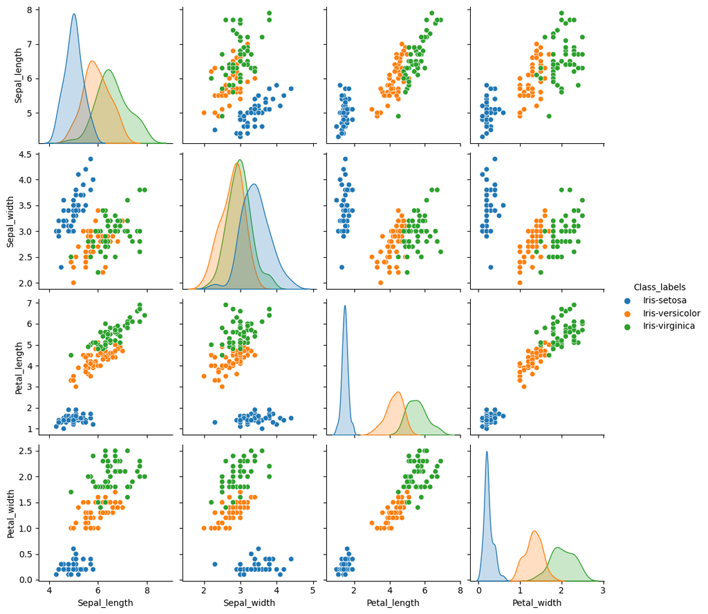

```python
import numpy as np
import matplotlib.pyplot as plt
import seaborn as sns
import pandas as pd
%matplotlib inline
import pandas as pd

columns = ['Sepal_length', 'Sepal_width', 'Petal_length', 'Petal_width', 'Class_labels']

df = pd.read_csv("C:\\Users\\cheen\\Downloads\\iris-flower-classification-project\\iris.data", names=columns)
df.head()

print(df.head())

df.describe()

sns.pairplot(df, hue='Class_labels')

df.info()
data = df.values

X=data[:,0:4]
Y=data[:,4]
#print(X)
#print(Y)

from sklearn.model_selection import train_test_split
X_train, X_test, y_train, y_test = train_test_split(X, Y, test_size=0.2)
print(X_train)

from sklearn.svm import SVC

model_svc = SVC()
model_svc.fit(X_train,y_train)
prediction1 = model_svc.predict(X_test)

from sklearn.metrics import accuracy_score
print(accuracy_score(y_test, prediction1)*100)
for i in range(len(prediction1)):
    print(y_test[i],prediction1[i])


from sklearn.linear_model import LogisticRegression
model_LR=LogisticRegression()
model_LR.fit(X_train,y_train)
```

```python
print(y_train)
```

```
['Iris-virginica' 'Iris-versicolor' 'Iris-setosa' 'Iris-virginica'
 'Iris-virginica' 'Iris-setosa' 'Iris-versicolor' 'Iris-virginica'
 'Iris-virginica' 'Iris-virginica' 'Iris-versicolor' 'Iris-setosa'
 'Iris-setosa' 'Iris-versicolor' 'Iris-setosa' 'Iris-setosa' 'Iris-setosa'
 'Iris-setosa' 'Iris-setosa' 'Iris-versicolor' 'Iris-versicolor'
 'Iris-virginica' 'Iris-virginica' 'Iris-setosa' 'Iris-setosa'
 'Iris-virginica' 'Iris-virginica' 'Iris-setosa' 'Iris-virginica'
 'Iris-virginica' 'Iris-versicolor' 'Iris-versicolor' 'Iris-setosa'
 'Iris-setosa' 'Iris-virginica' 'Iris-virginica' 'Iris-virginica'
 'Iris-virginica' 'Iris-versicolor' 'Iris-versicolor' 'Iris-setosa'
 'Iris-setosa' 'Iris-versicolor' 'Iris-versicolor' 'Iris-versicolor'
 'Iris-virginica' 'Iris-versicolor' 'Iris-virginica' 'Iris-setosa'
 'Iris-versicolor' 'Iris-virginica' 'Iris-virginica' 'Iris-setosa'
 'Iris-virginica' 'Iris-versicolor' 'Iris-setosa' 'Iris-versicolor'
 'Iris-versicolor' 'Iris-versicolor' 'Iris-setosa' 'Iris-setosa'
 'Iris-virginica' 'Iris-setosa' 'Iris-versicolor' 'Iris-virginica'
 'Iris-versicolor' 'Iris-versicolor' 'Iris-setosa' 'Iris-virginica'
 'Iris-setosa' 'Iris-setosa' 'Iris-setosa' 'Iris-virginica'
 'Iris-virginica' 'Iris-versicolor' 'Iris-virginica' 'Iris-versicolor'
 'Iris-virginica' 'Iris-versicolor' 'Iris-setosa' 'Iris-versicolor'
 'Iris-virginica' 'Iris-virginica' 'Iris-versicolor' 'Iris-versicolor'
 'Iris-versicolor' 'Iris-setosa' 'Iris-versicolor' 'Iris-versicolor'
 'Iris-versicolor' 'Iris-versicolor' 'Iris-setosa' 'Iris-versicolor'
 'Iris-setosa' 'Iris-setosa' 'Iris-versicolor' 'Iris-versicolor'
 'Iris-virginica' 'Iris-virginica' 'Iris-setosa' 'Iris-virginica'
 'Iris-setosa' 'Iris-setosa' 'Iris-virginica' 'Iris-virginica'
 'Iris-versicolor' 'Iris-versicolor' 'Iris-virginica' 'Iris-versicolor'
 'Iris-setosa' 'Iris-versicolor' 'Iris-virginica' 'Iris-setosa'
 'Iris-setosa' 'Iris-setosa' 'Iris-virginica' 'Iris-setosa' 'Iris-setosa'
 'Iris-virginica' 'Iris-versicolor']
```

```python
pred2 = model_LR.predict(X_test)
from sklearn.metrics import accuracy_score
print(accuracy_score(y_test, pred2)*100)
for i in range(len(prediction1)):
    print(y_test[i],prediction1[i])
```

```
100.0
Iris-versicolor Iris-versicolor
Iris-setosa Iris-setosa
Iris-setosa Iris-setosa
Iris-virginica Iris-virginica
Iris-setosa Iris-setosa
Iris-virginica Iris-virginica
Iris-setosa Iris-setosa
Iris-virginica Iris-virginica
Iris-virginica Iris-virginica
Iris-virginica Iris-virginica
Iris-versicolor Iris-versicolor
Iris-setosa Iris-setosa
Iris-virginica Iris-virginica
Iris-versicolor Iris-versicolor
Iris-setosa Iris-setosa
Iris-virginica Iris-virginica
Iris-virginica Iris-virginica
Iris-versicolor Iris-versicolor
Iris-virginica Iris-virginica
Iris-versicolor Iris-versicolor
Iris-setosa Iris-setosa
Iris-versicolor Iris-versicolor
Iris-setosa Iris-setosa
Iris-versicolor Iris-versicolor
Iris-setosa Iris-setosa
Iris-versicolor Iris-versicolor
Iris-versicolor Iris-versicolor
Iris-versicolor Iris-versicolor
Iris-virginica Iris-virginica
Iris-virginica Iris-virginica
```

```python
from sklearn.tree import DecisionTreeClassifier
model_DTC=DecisionTreeClassifier()
model_DTC.fit(X_train,y_train)
```

```
DecisionTreeClassifier()
```

```python
pred3 = model_svc.predict(X_test)
from sklearn.metrics import accuracy_score
print(accuracy_score(y_test, pred3))
```

```
1.0
```

```python
from sklearn.metrics import classification_report
print(classification_report(y_test, pred2))
```

```
                 precision    recall  f1-score   support

    Iris-setosa       1.00      1.00      1.00         9
Iris-versicolor       1.00      1.00      1.00        10
 Iris-virginica       1.00      1.00      1.00        11

       accuracy                           1.00        30
      macro avg       1.00      1.00      1.00        30
   weighted avg       1.00      1.00      1.00        30
```

### END OF PROJECT 2

# NAME OF STUDENT = ADARSH AGRAWAL

# ENROLLED IN COURSE = AI WITH PYTHON

# SUBMISSION OF FINAL ASSIGNMENT